# act_report

## Act Report

**By: Grant Glass**

This project will assure you have mastered the subjects covered in the statistics lessons. The hope is to have this project be as comprehensive of these topics as possible. Good luck!

- Storing, analyzing, and visualizing data

### Visualizing Data for this Project

## Insight 1: How well did machine learning do at predicting?

```python
images_df.describe()
```

|  | tweet_id | img_num | p1_conf | p2_conf | p3_conf |
| --- | --- | --- | --- | --- | --- |
| count | 2.075000e+03 | 2075.000000 | 2075.000000 | 2.075000e+03 | 2.075000e+03 |
| mean | 7.384514e+17 | 1.203855 | 0.594548 | 1.345886e-01 | 6.032417e-02 |
| std | 6.785203e+16 | 0.561875 | 0.271174 | 1.006657e-01 | 5.090593e-02 |
| min | 6.660209e+17 | 1.000000 | 0.044333 | 1.011300e-08 | 1.740170e-10 |
| 25% | 6.764835e+17 | 1.000000 | 0.364412 | 5.388625e-02 | 1.622240e-02 |
| 50% | 7.119988e+17 | 1.000000 | 0.588230 | 1.181810e-01 | 4.944380e-02 |
| 75% | 7.932034e+17 | 1.000000 | 0.843855 | 1.955655e-01 | 9.180755e-02 |
| max | 8.924206e+17 | 4.000000 | 1.000000 | 4.880140e-01 | 2.734190e-01 |

Results: p1_conf on the high end does a good job at predicting(confidence). While p2 and p3 do pretty bad.

```python
#let's look at the most confident tweet
best = images_df[images_df.p1_conf == 1.0]
best
```

|  | tweet_id | jpg_url | img_num | p1 | p1_conf | p1_dog | p2 | p2_conf | p2_dog | p3 | p3_conf | p3_dog |
| --- | --- | --- | --- | --- | --- | --- | --- | --- | --- | --- | --- | --- |
| 106 | 667866724293877760 | https://pbs.twimg.com/media/CUS9PlUWwAANeAD.jpg | 1 | jigsaw_puzzle | 1.0 | False | prayer_rug | 1.011300e-08 | False | doormat | 1.740170e-10 | False |

ok, so it nailed the jigsaw_pizzle in the picture! couldn't find the dog though. None of the MLAs could find the dog, but it is interesting to note that a jigsaw, prayer rug, and doormat all look very similiar to a computer. The "fuzziness" of their perceived textual causes a jigsaw to look like a rug. If the computer had more than just images, it might be able to know the difference. But the three items do appear very similar to one another.

## Insight 2: When did WepostDogs make the most tweets?

```python
#convert timestamp from object to datetime
final_df.timestamp = pd.to_datetime(final_df.timestamp)
```

```python
final_df.info()
```

```
<class 'pandas.core.frame.DataFrame'>
Int64Index: 1994 entries, 0 to 2355
Data columns (total 10 columns):
tweet_id              1994 non-null int64
timestamp             1994 non-null datetime64[ns]
source                1994 non-null object
text                  1994 non-null object
expanded_urls         1994 non-null object
rating_numerator      1994 non-null int64
rating_denominator    1994 non-null int64
name                  1994 non-null object
stage                 1994 non-null object
breed                 1994 non-null object
dtypes: datetime64[ns](1), int64(3), object(6)
memory usage: 171.4+ KB
```

```python
#time order the tweets in the dataset
final_df['timestamp'].apply(lambda x: x.strftime('%Y-%m')).value_counts().sort_index()
```

```
2015-11    296
2015-12    367
2016-01    169
2016-02    111
2016-03    120
2016-04     54
2016-05     57
2016-06     81
2016-07     88
2016-08     59
2016-09     63
2016-10     65
2016-11     53
2016-12     54
2017-01     66
2017-02     64
2017-03     48
2017-04     41
2017-05     43
2017-06     44
2017-07     49
2017-08      2
Name: timestamp, dtype: int64
```

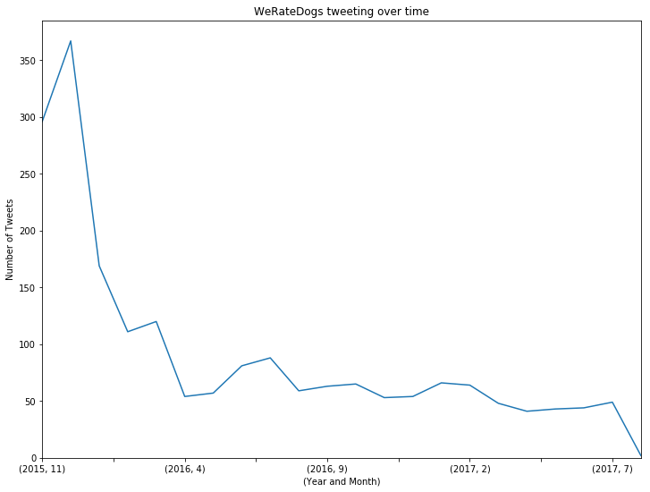

```python
#Let's see that data:
plt.rcParams["figure.figsize"] = [12, 9]
data = final_df.tweet_id.groupby([final_df["timestamp"].dt.year, final_df["timestamp"].dt.month]).count()
ax = data.plot('line', title='WeRateDogs tweeting over time')
ax.set_xlabel("(Year and Month)")
ax.set_ylabel("Number of Tweets")
ax.set_ylim(0, )
plt.savefig('tweet_trend')
```

So it looks like this was very popular in its second month(probably took a little to get going), but there is a sharp decline in less than six months. This didn't last very long. By the time we get to the end of 2017, there is a large droppoff of engagement.

However, this gives us a good indicator of how long virality lasts. It lasts less than 6 months. This seems on par with other cultural phenonomn.

Line graphs are good for looking at changes in time.

## Insight 3: What are the most common dog names?

```
Text(0,0.5,u'Number of Dogs')
```

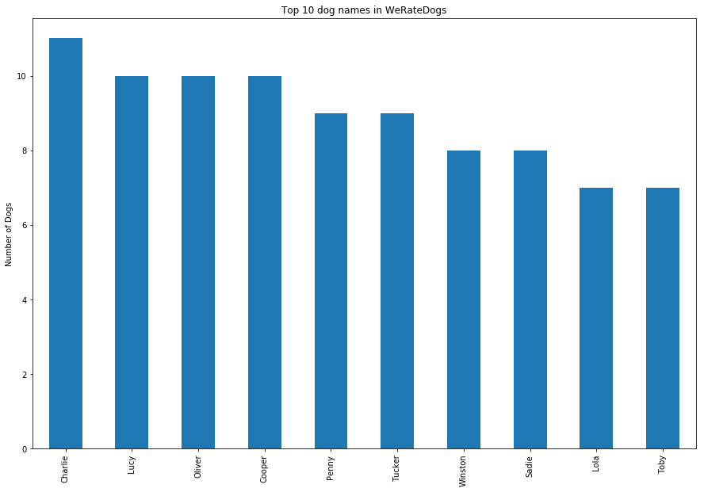

```python
df.name.value_counts()[1:11].plot('bar', figsize=(15,10), title='Top 10 dog names in WeRateDogs').set_ylabel("Number of Dogs")
```

Charlie is our winner! Numbers might make one think that Lucy, Oliver, and Cooper are farther apart than what they appear on this bar graph. Visualizations like this are helpful for showing how close variables are to one another.

## Visualization: Correlation Matrix

```python
#Plotting a diagonal correlation matrix
corr = images_df.corr()
```

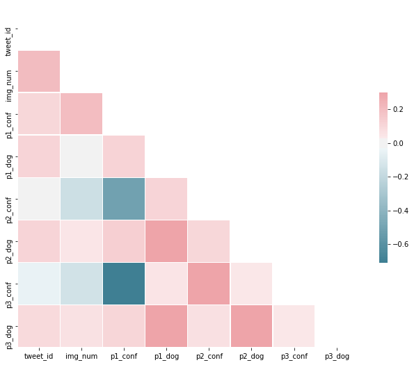

```python
mask = np.triu(np.ones_like(corr, dtype=np.bool))
f, ax = plt.subplots(figsize=(11, 9))
cmap = sns.diverging_palette(220, 10, as_cmap=True)
sns.heatmap(corr, mask=mask, cmap=cmap, vmax=.3, center=0,
            square=True, linewidths=.5, cbar_kws={"shrink": .5})
```